# 586 Project - Oreoscoptes Analysis

Xinyu Dong, ZiYing(Sophie) Chen, Matthew Yau

2023-04-23

```
## spatstat.geom 3.1-0
```

```
## spatstat.random 3.1-4
```

```
## spatstat.explore 3.1-0
```

```
## spatstat.model 3.2-1
```

```
## spatstat.linnet 3.0-6
```

```
##
## spatstat 3.0-3
## For an introduction to spatstat, type 'beginner'
```

[output not shown]

[output not shown]

## Introduction

The Sage Thrasher is a medium-sized passerine bird from the family Mimidae, which also includes mockingbirds, tremblers, and New World catbirds. It is the only member of the genus Oreoscoptes. This seems less close to the Caribbean thrashers, but rather to the mockingbirds instead.

The Sage Thrasher is one of the rarest birds in Canada. Prior to 1930, there were 30 or more nesting pairs at up to six sites; in recent years, only 4 - 10 pairs have been seen at one or two sites. Over the past 70 years, there has been an estimated 50 percent loss of habitat for the Sage Thrasher. Heavy grazing and clearing of sagebrush to improve range conditions has seriously affected the availability of suitable nesting areas. The preservation of remaining Sage Thrashers depends on the careful management of remaining large tracts of dense sagebrush habitat. Heavy grazing of sagebrush sites should be avoided, and areas cleared of sagebrush should be restored whenever possible.

The data used in this reports come from `eBirds`. `eBird` is a collective enterprise that takes a novel approach to citizen science by developing cooperative partnerships among experts in a wide range of fields: population ecologists, conservation biologists, quantitative ecologists, statisticians, computer scientists, GIS and informatics specialists, application developers, and data administrators.

## Methods

### Detailed Analytical Workflow

1. Load all packages we need. Please refer to **Statistical Packages**.
2. Data processing:
- Load Oreoscoptes data by `df <- read.csv("BC_data.csv", stringsAsFactors = FALSE)`.
- Generate a dataframe `coord` with longitude and latitude in BC_data by

  `coord <- df[,c('decimalLatitude','decimalLongitude')]`.
- Clean the data by removing the observations with NA, `coord <- na.omit(coord)`.
- Visualize the data `plot(coord$decimalLatitude, coord$decimalLongitude)`.
- By using the coordinates function to create a new object with the spatial coordinates and then setting its CRS using proj4string, we can ensure that our spatial analyses are performed correctly, and we can compare our results with other analyses that use the same CRS.

  ```
  coordinates(coord)<- ~decimalLongitude+decimalLatitude

  proj4string(coord) <- CRS("+proj=longlat +datum=WGS84")

  coord_conv <- spTransform(coord,CRS("+proj=aea +lat_0=45 +lon_0=-126 +lat_1=50

                +lat_2=58.5 +x_0=1000000 +y_0=0 +datum=NAD83 +units=m +no_defs"))
  ```

- Load the covariates data by `load("BC_Covariates.Rda")`.
- Define the observation area, window, by `win = as.owin(DATA$Window)`
- create ppp object with coordination and the window by

  ```
  ppp_birds <- ppp(coord_conv@coords[,1],

               coord_conv@coords[,2],

               window=win)
  ```

3. Inspecting and Exploring data
- Check the spread of the bird `plot(ppp_birds)`
- Check homogeneity, perform quardratic test. `Q <- quadratcount(bei, nx = 10, ny = 10) quadrat.test(Q)`
- Identify the class of each potential covariate by `sapply(DATA, class)`
- Visualise each potential covariate using methods appropriate to each object class.

  ```
  potential <- c("Window", "Elevation", "Forest", "HFI", "Dist_Water")

  for (i in potential){
    plot(DATA[[i]], main = i)
    points(ppp_birds$x, ppp_birds$y, pch = 19, col = "white", cex = 0.6)
    points(ppp_birds$x, ppp_birds$y, pch = 19, col = "black", cex = 0.4)
  }
  ```

- Plotting a point pattern by `plot(ppp_birds)`
4. Model Building - Regression
5. Model Validation
- Quardratic Counting
- Partial Residual Plots

## Results

By looking at Figure 1, we can see that the data is not homogeneous dataset as the birds tend to be clustered in south areas of BC, whereas others have no birds at all, and we conduct a quardratic test to support the inhomogeneous assumption (small p-value).

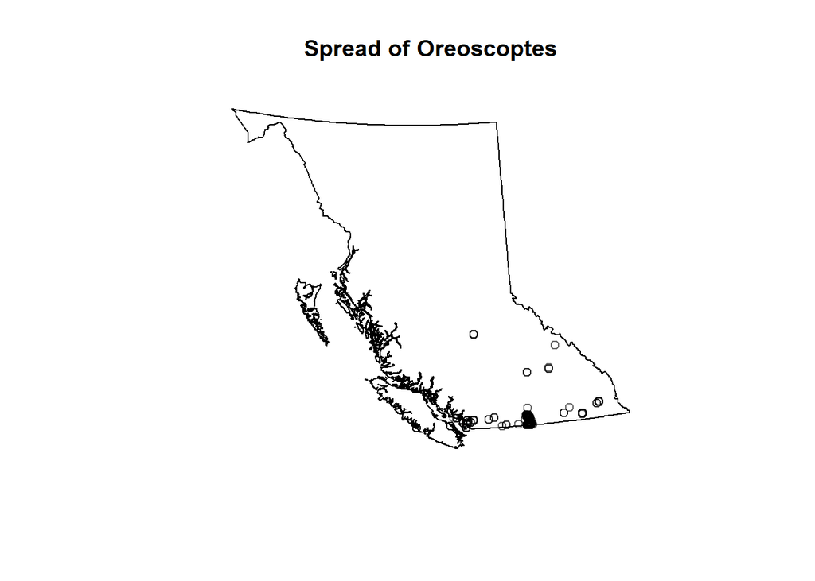

Oreoscoptes in BC

```
##
##  Chi-squared test of CSR using quadrat counts
##
## data:
## X2 = 71836, df = 63, p-value < 2.2e-16
## alternative hypothesis: two.sided
##
## Quadrats: 64 tiles (irregular windows)
```

## Conclusion

- The partial graph, still does not go well to capture the distribution.
- The reason is more more the variables selection rather than the model.
- Though `The distance to water` and `elevation` may be explainable in some sense, to accurately fit the location, we may need more co-variate.
- For example, a reasonable guess is the average temperature, as all this species are densely located in the south end of BC.
- To further improve the fitting, we can incoprate `temperature` to our model

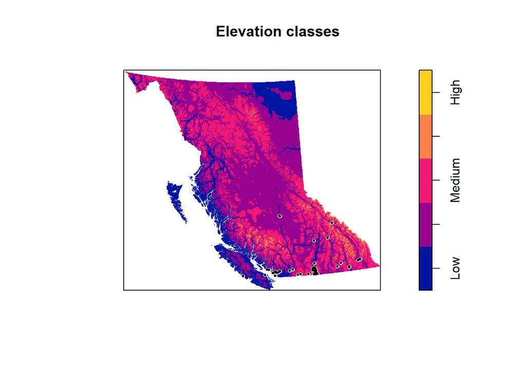

## Variable of Intrest

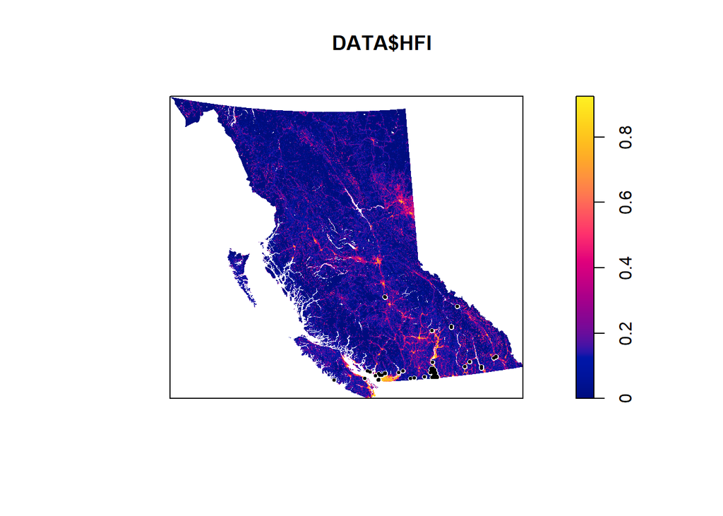

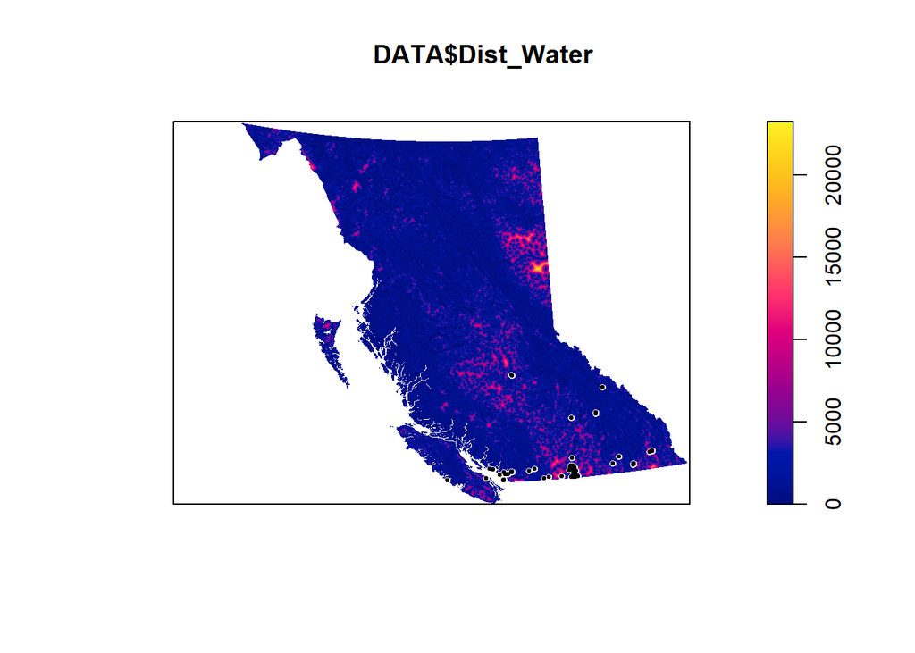

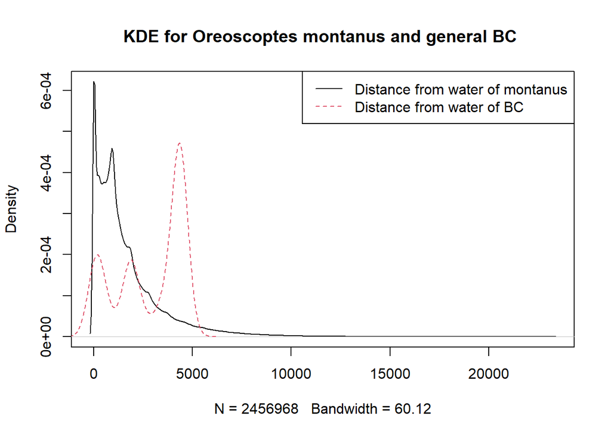

- We can see the the distribution density of Oreoscoptes montanus is highly related to the `The distance to water`. Therefore, we will adopt this variabel as our covariable to further investigate how the distribution of Oreoscoptes montanus is related to the distance to water.

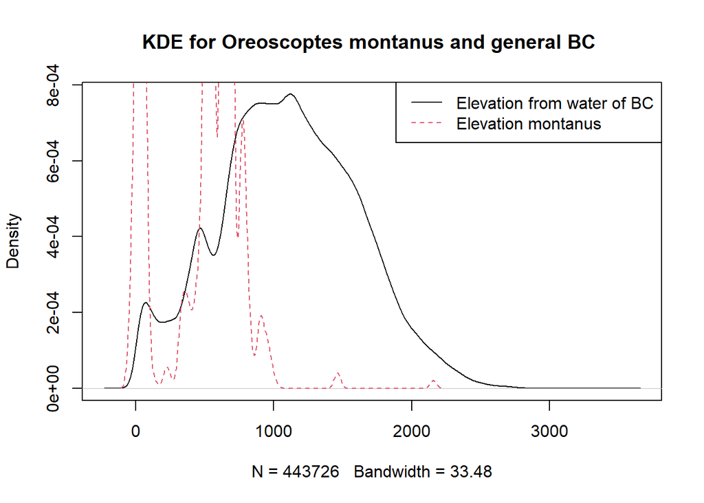

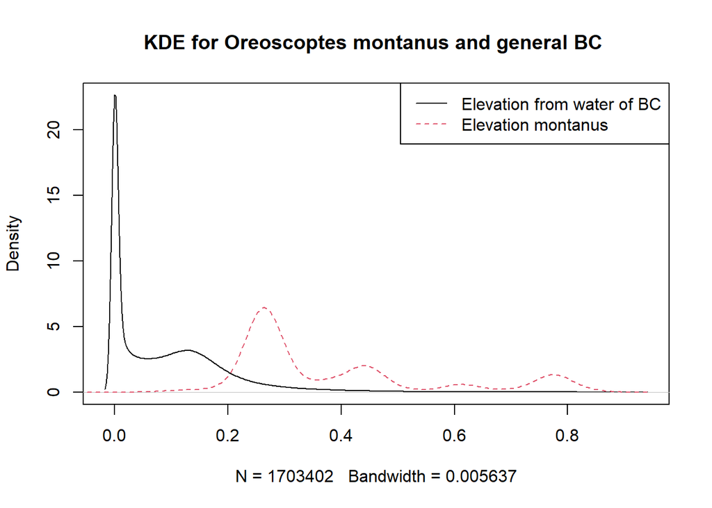

## Distribution Pattern

### Kernel Likelihoood Estimation(Meaningless)

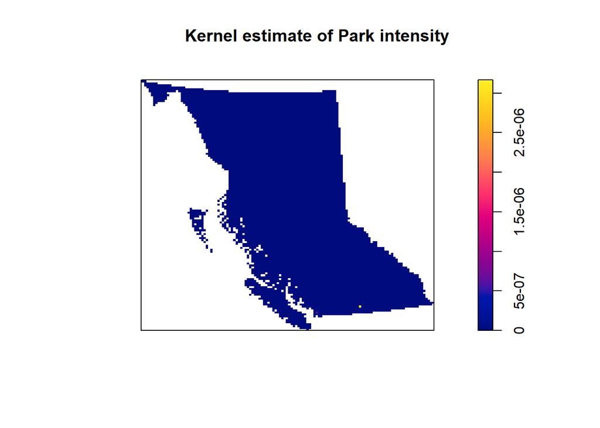

### Hotspot Analysis

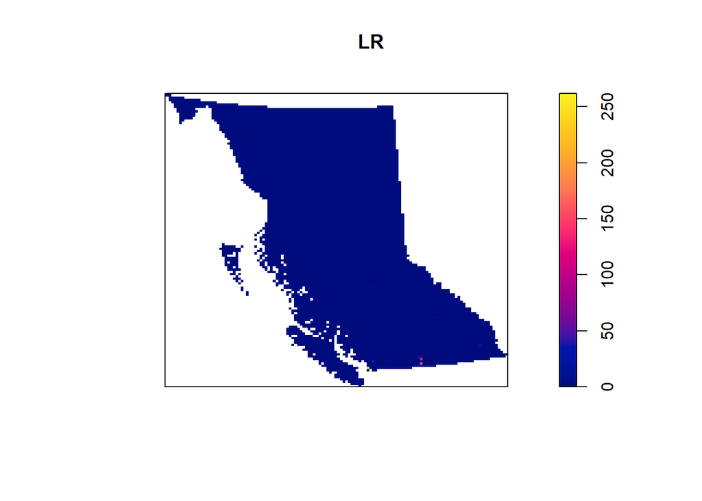

## Co-variates check

### $\rho$ Function

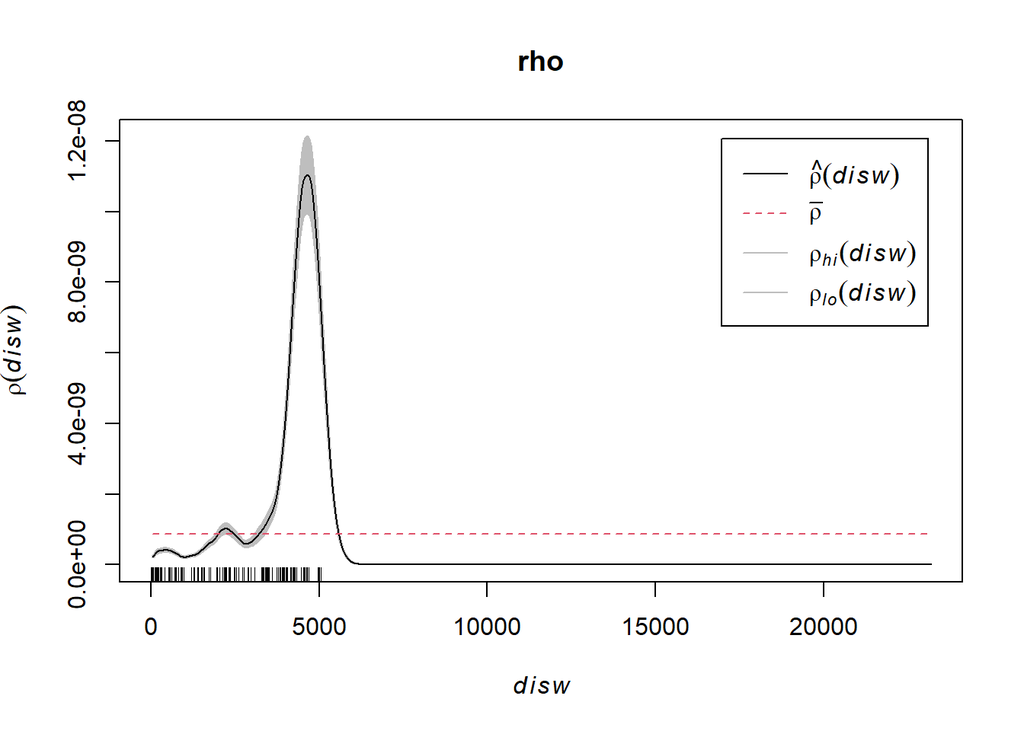

For Oreoscoptes montanus, they seems to have a specific preference for habitants in terms of the distance to water. From the graph, there is a narrow bandth.

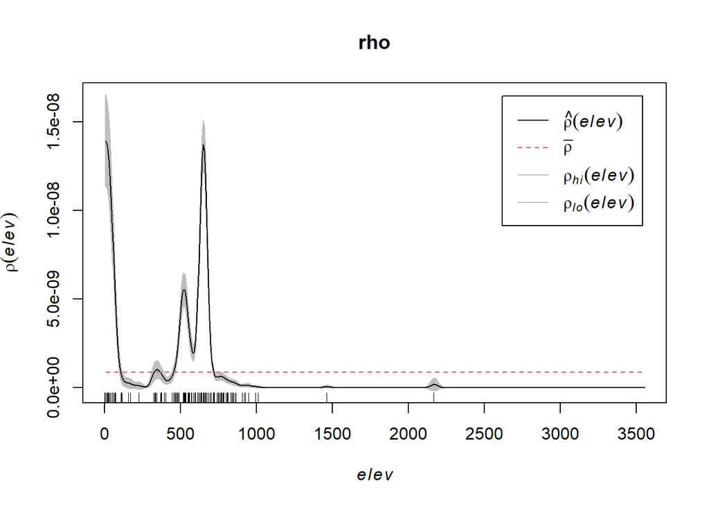

For Oreoscoptes montanus, they seems have two clusters: one group living near the 0 elevation, and another group lives in around 500m.

To conclude, `distance to water` is an good candidate of co-variates, and `elevation` has the potential to be a sedonary covariates. We will use those two in our Regression Analysis. `

## Regression

Now we konw that `distance to water` and `elevation` plays a crucial role if we want to dig out where we could find these birds, which only mean this varible can help us even *predict* where this birds will live, based on theri current habitats.

This is of crucial meaning in identify potential location for re-habitation. ….

Based on the initial graph, a reasonable form of the model is

```
##                          Estimate       S.E.     CI95.lo     CI95.hi Ztest
## (Intercept)            -21.902675 0.07254791 -22.0448659 -21.7604833   ***
## Elevation_scaled        -1.670524 0.04966113  -1.7678576  -1.5731895   ***
## Dist_Water_scaled        1.713136 0.07037995   1.5751940   1.8510784   ***
## I(Dist_Water_scaled^2)  -0.549098 0.03273082  -0.6132493  -0.4849468   ***
##                              Zval
## (Intercept)            -301.90635
## Elevation_scaled        -33.63845
## Dist_Water_scaled        24.34125
## I(Dist_Water_scaled^2)  -16.77618
```

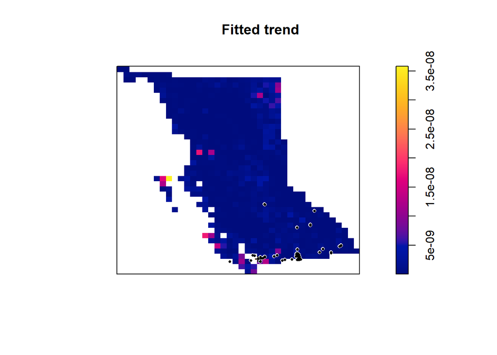

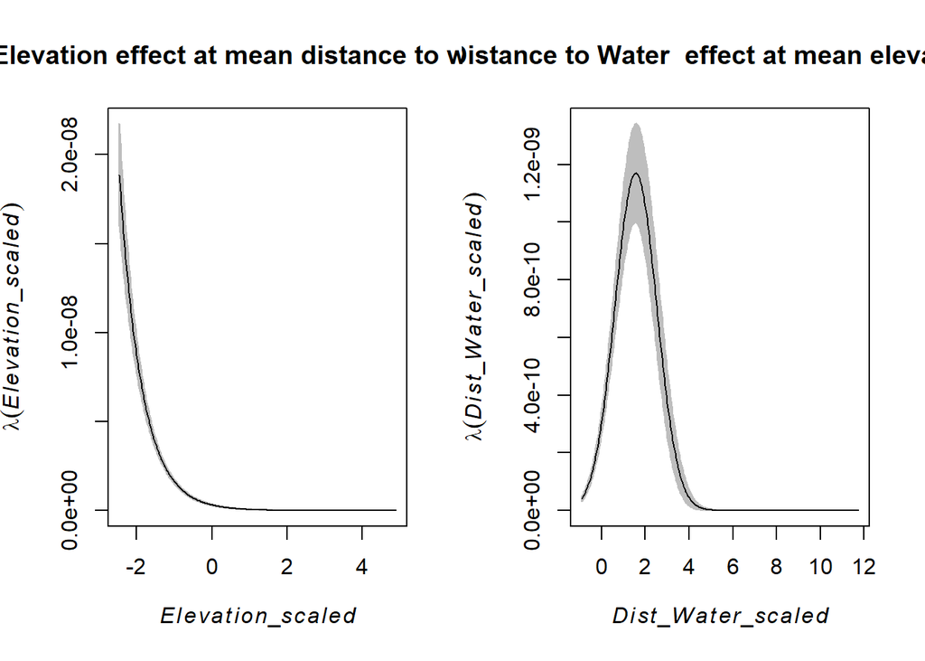

## Model Validation

### Quadrat counting

```
##
##  Chi-squared test of fitted Poisson model 'fit' using quadrat counts
##
## data:  data from fit
## X2 = 3195.1, df = 4, p-value < 2.2e-16
## alternative hypothesis: two.sided
##
## Quadrats: 8 tiles (irregular windows)
```

The small p value tells us that there’s a significant deviation from our model’s predictions. Let us dig out how to improve it.

### Partial residual plots

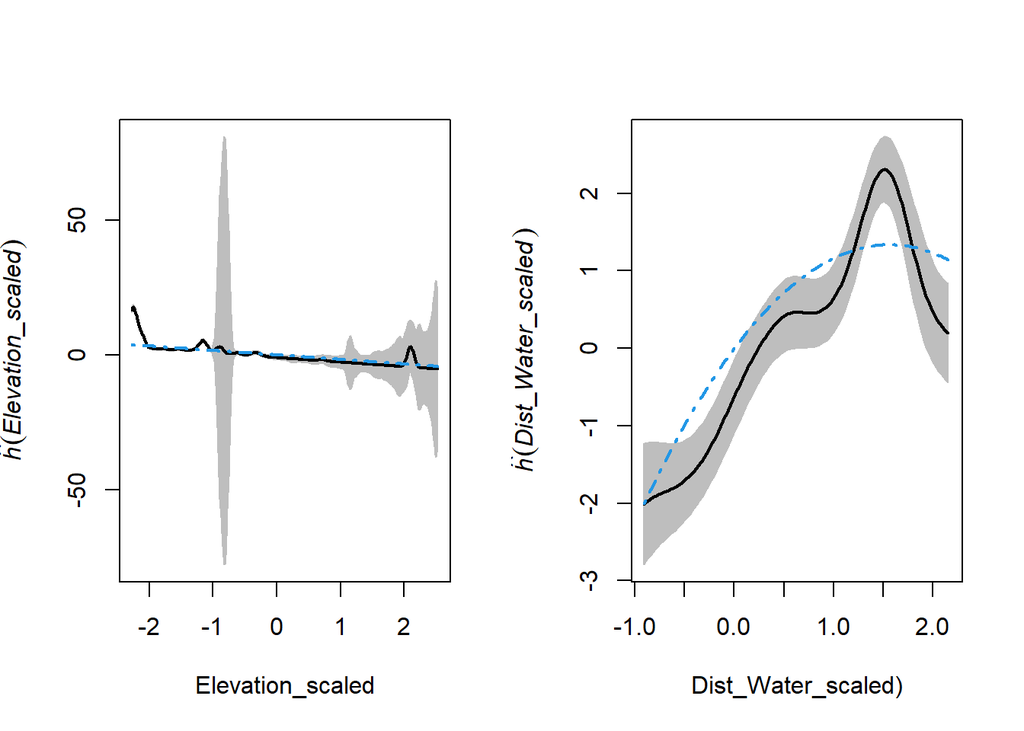

From these figures we can see that the quadratic terms are not capturing the patterns in our data particularly well. As an improvement, we could try adding higher-order polynomials, but polynomials can be unstable. In this situation, it may be worth switching from a linear modelling framework, to an additive modelling framework (i.e., GAMs).

### GAM Not Valid,still ‘df’ was too small

```
## Nonstationary Poisson process
## Fitted to point pattern dataset 'ppp_birds'
##
## Log intensity:  ~bs(Elevation_scaled, 2) + bs(Dist_Water_scaled, 3)
##
## Fitted trend coefficients:
##               (Intercept)  bs(Elevation_scaled, 2)1  bs(Elevation_scaled, 2)2
##                 -17.02136                 -25.76851                 140.00830
##  bs(Elevation_scaled, 2)3 bs(Dist_Water_scaled, 3)1 bs(Dist_Water_scaled, 3)2
##                -807.98539                 -20.66131                 246.95447
## bs(Dist_Water_scaled, 3)3
##               -1673.64508
##
## For standard errors, type coef(summary(x))
```

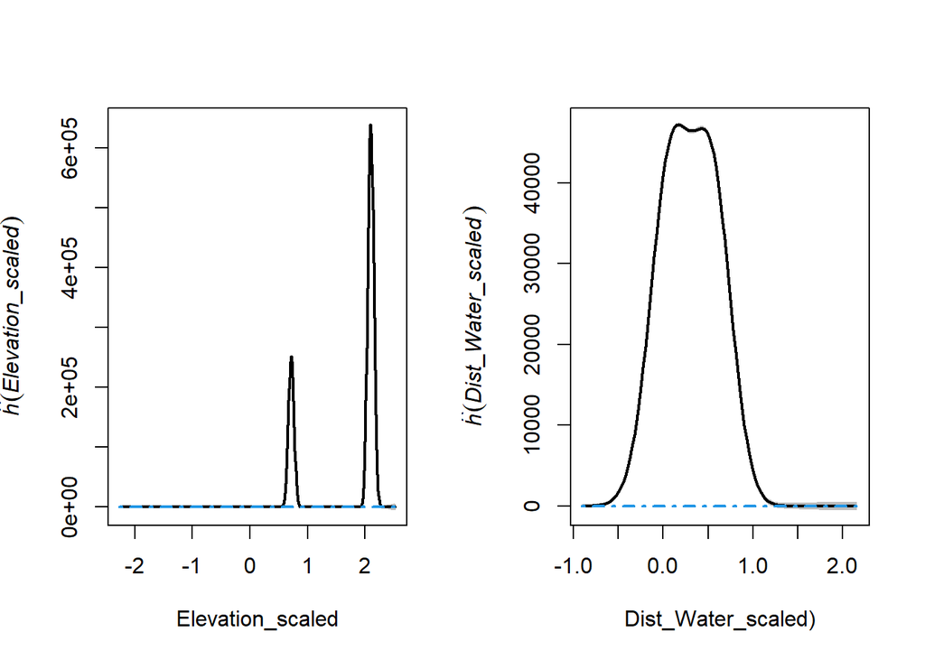

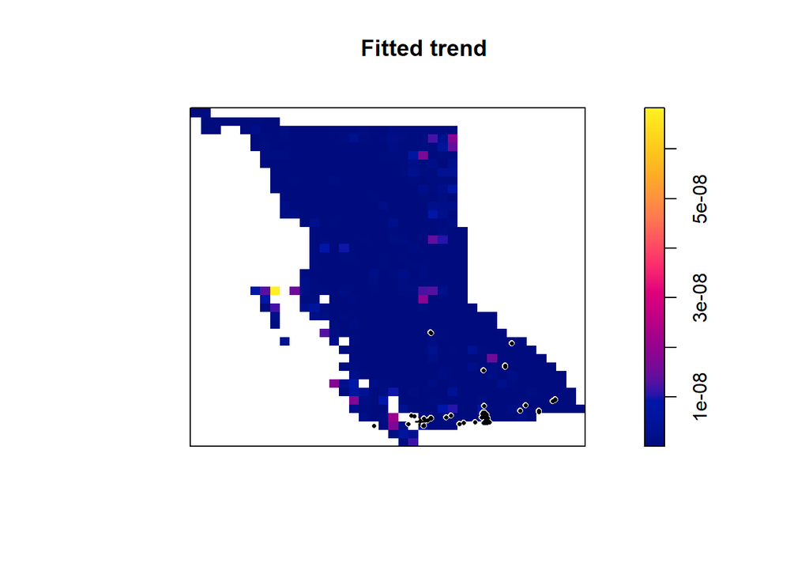

- For a `GAM`, model, it looks like we do not have enough data to fit.